```python
# import the Python libraries for EDA and Preprocessing
import pandas as pd
import numpy as np
import seaborn as sns
import matplotlib.pyplot as plt

#read dataset
bikes = pd.read_csv("metro.csv", low_memory=False)
bikes.head()
```

|  | trip_id | duration | start_time | end_time | start_station | start_lat | start_lon | end_station | end_lat | end_lon | bike_id | plan_duration | trip_route_category | passholder_type | bike_type |
| --- | --- | --- | --- | --- | --- | --- | --- | --- | --- | --- | --- | --- | --- | --- | --- |
| 0 | 124657107 | 5 | 7/1/2019 0:04 | 7/1/2019 0:09 | 4312 | 34.066990 | -118.290878 | 4410 | 34.063351 | -118.296799 | 6168 | 30 | One Way | Monthly Pass | standard |
| 1 | 124657587 | 9 | 7/1/2019 0:07 | 7/1/2019 0:16 | 3066 | 34.063389 | -118.236160 | 3066 | 34.063389 | -118.236160 | 17584 | 30 | Round Trip | Monthly Pass | electric |
| 2 | 124658068 | 5 | 7/1/2019 0:20 | 7/1/2019 0:25 | 4410 | 34.063351 | -118.296799 | 4312 | 34.066990 | -118.290878 | 18920 | 30 | One Way | Monthly Pass | electric |
| 3 | 124659747 | 20 | 7/1/2019 0:44 | 7/1/2019 1:04 | 3045 | 34.028511 | -118.256668 | 4275 | 34.012520 | -118.285896 | 6016 | 1 | One Way | Walk-up | standard |
| 4 | 124660227 | 27 | 7/1/2019 0:44 | 7/1/2019 1:11 | 3035 | 34.048401 | -118.260948 | 3049 | 34.056969 | -118.253593 | 5867 | 30 | One Way | Monthly Pass | standard |

# Exploratory Data Analysis

```python
#Dataset summary
bikes.info()
```

```
<class 'pandas.core.frame.DataFrame'>
RangeIndex: 92124 entries, 0 to 92123
Data columns (total 15 columns):
 #   Column               Non-Null Count  Dtype
---  ------               --------------  -----
 0   trip_id              92124 non-null  int64
 1   duration             92124 non-null  int64
 2   start_time           92124 non-null  object
 3   end_time             92124 non-null  object
 4   start_station        92124 non-null  int64
 5   start_lat            89985 non-null  float64
 6   start_lon            89985 non-null  float64
 7   end_station          92124 non-null  int64
 8   end_lat              88052 non-null  float64
 9   end_lon              88052 non-null  float64
 10  bike_id              92124 non-null  object
 11  plan_duration        92124 non-null  int64
 12  trip_route_category  92124 non-null  object
 13  passholder_type      92124 non-null  object
 14  bike_type            92124 non-null  object
dtypes: float64(4), int64(5), object(6)
memory usage: 10.5+ MB
```

After using the *info* method, it can be seen that there are 92124 records in this dataset.

In addition, two relevant pieces of information can be found for each column. First, the number of non-missing values for each attribute; and second, the datatype of each attribute.

When it comes to missing values, there appears to be 4 attributes with missing values: **start_lat**, **start_lon** (both with 92124-89985=2139 missing values), **end_lat** and **end_lon** (both with 92124-88052=4072 missing values); other attributes do not contain any missing values.

Regarding attribute datatypes, most datatypes are suitable for each attribute; **start_time** and **end_time** are incorrectly stored as object datatypes and should instead be kept as datetime datatypes, along with **bike_id** which should be kept as an integer datatype. These issues will be addressed during preprocessing.

```python
#Print duplicated records
duplicates = bikes[bikes.duplicated()]
duplicates
```

|  | trip_id | duration | start_time | end_time | start_station | start_lat | start_lon | end_station | end_lat | end_lon | bike_id | plan_duration | trip_route_category | passholder_type | bike_type |
| --- | --- | --- | --- | --- | --- | --- | --- | --- | --- | --- | --- | --- | --- | --- | --- |

*Using* the *duplicated* method, the duplicate rows can be printed; as no rows were printed, it indicates that there are no duplicate records.

```python
#Descriptive Statistics
bikes[['duration', 'start_lat', 'start_lon', 'end_lat', 'end_lon', 'plan_duration']].describe()
```

|  | duration | start_lat | start_lon | end_lat | end_lon | plan_duration |
| --- | --- | --- | --- | --- | --- | --- |
| count | 92124.000000 | 89985.000000 | 89985.000000 | 88052.000000 | 88052.000000 | 92124.000000 |
| mean | 33.168588 | 34.034786 | -118.287893 | 34.034895 | -118.286699 | 60.290977 |
| std | 129.057841 | 0.058803 | 0.073501 | 0.058790 | 0.072628 | 111.141364 |
| min | 1.000000 | 33.710979 | -118.495422 | 33.710979 | -118.495422 | 1.000000 |
| 25% | 6.000000 | 34.035801 | -118.281181 | 34.037048 | -118.280952 | 1.000000 |
| 50% | 12.000000 | 34.046810 | -118.258537 | 34.046810 | -118.258537 | 30.000000 |
| 75% | 22.000000 | 34.051941 | -118.248253 | 34.051941 | -118.248253 | 30.000000 |
| max | 1440.000000 | 34.177662 | -118.231277 | 34.177662 | -118.231277 | 999.000000 |

Here, descriptive statistics on each relavant attribute was calculated. These are the truly numerical attributes present in the dataset; while there are other attributes stored in a numerical datatype such as **trip_id** or **start_station**, these attributes are actually nominal as they are just identifiers for each trip, bike or station. If the columns are not specified, Pandas will calculate descriptive statistics even for those nominal attributes as they are stored in a numerical datatype.

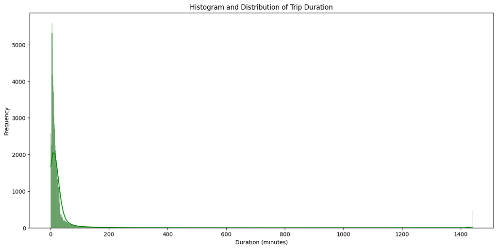

```python
#Histogram and Distribution of Trip Duration
plt.figure(figsize=(15, 7)) #Plot dimensions
sns.histplot(bikes['duration'], kde=True, bins=1440, color='green') #Histogram plot function using Seaborn library
plt.title('Histogram and Distribution of Trip Duration') #Title of plot
plt.xlabel('Duration (minutes)') #X-axis label
plt.ylabel('Frequency') #Y-axis label
plt.show()
```

In the above graph, the frequency of different trip times is plotted in a histogram. A Density Estimation Line is plotted on top of the histogram showing the probability distribution for each trip duration.

On the far end of the graph there appears to be a number of outlier values at around 1450 minutes (about 24 hours). When looking back at the *describe* method, the maximum duration time is 1440 minutes which is exactly 24 hours. This is causing the graph to be malformed and is affecting the Kernel Density Estimation line.

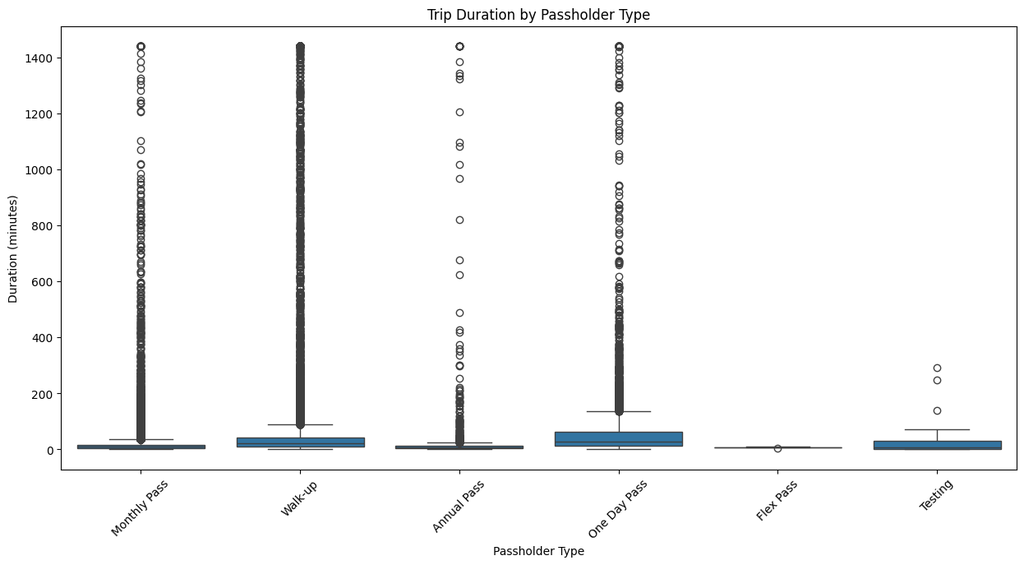

```python
#Trip Duration by Passholder Type Box Plots
plt.figure(figsize=(15, 7)) #Plot Dimensions
sns.boxplot(data=bikes, x='passholder_type', y='duration') #Box Plot function using Seaborn library
plt.title('Trip Duration by Passholder Type') #Title of plot
plt.xlabel('Passholder Type') #X-axis label
plt.ylabel('Duration (minutes)') #Y-axis label
plt.xticks(rotation=45)
plt.show()
```

In the above graph, box plots of the duration for each bike pass is plotted. There also appears to be a wrong category called 'Testing'; the rows with this category will be removed as this is most probably a category made to test the dataset or a category added when technicians wanted to test rent a bike. All of the Passholder Types have very high upper bound outlier values, reaching the maximum of 1440 minutes, except 'Flex Pass' and 'Testing'.

```python
#Count trips with each Passholder Type
bikes['passholder_type'].value_counts()
```

| passholder_type | count |
| --- | --- |
| Monthly Pass | 57175 |
| Walk-up | 23502 |
| Annual Pass | 6220 |
| One Day Pass | 5175 |
| Testing | 46 |
| Flex Pass | 6 |

**dtype:** int64

Using the above *value_counts* method, it can be observed that the most common passholder types are 'Monthly Pass', 'Walk-up', 'Annual Pass' and 'One Day Pass'; there were only 6 trips which had a passholder type of 'Flex Pass'. This extremely low number of 'Flex Pass' holders could indicate it is either a brand new or discontinued bike pass type.

# Preprocessing

```python
bikes = bikes.dropna() #Drop records with at least one missing value
bikes.info()
```

```
<class 'pandas.core.frame.DataFrame'>
Index: 86760 entries, 0 to 92122
Data columns (total 15 columns):
 #   Column               Non-Null Count  Dtype
---  ------               --------------  -----
 0   trip_id              86760 non-null  int64
 1   duration             86760 non-null  int64
 2   start_time           86760 non-null  object
 3   end_time             86760 non-null  object
 4   start_station        86760 non-null  int64
 5   start_lat            86760 non-null  float64
 6   start_lon            86760 non-null  float64
 7   end_station          86760 non-null  int64
 8   end_lat              86760 non-null  float64
 9   end_lon              86760 non-null  float64
 10  bike_id              86760 non-null  object
 11  plan_duration        86760 non-null  int64
 12  trip_route_category  86760 non-null  object
 13  passholder_type      86760 non-null  object
 14  bike_type            86760 non-null  object
dtypes: float64(4), int64(5), object(6)
memory usage: 10.6+ MB
```

Above, the rows with missing values in the coordinate attributes have been dropped. Imputing the missing coordinates would be extremely challenging as the number of unique stations with known coordinates would have to be stored and then each station in the missing records would have to be cross-referenced to impute missing coordinate data; if there are no matching stations, then the records would have to be dropped anyways as imputing missing data with a value such as mean is not suitable in this case. Conversely, there are only 5364 records with missing values (5.8% of the original dataset) and as such, dropping those records would only remove a small and insignificant proportion of the dataset.

```python
bikes['start_time'] = pd.to_datetime(bikes['start_time'], errors='coerce') #Change 'start_time' datatype to datetime format
bikes['end_time'] = pd.to_datetime(bikes['end_time'], errors='coerce') #Change 'end_time' datatype to datetime format
bikes.info()
```

```
<class 'pandas.core.frame.DataFrame'>
Index: 86760 entries, 0 to 92122
Data columns (total 15 columns):
 #   Column               Non-Null Count  Dtype
---  ------               --------------  -----
 0   trip_id              86760 non-null  int64
 1   duration             86760 non-null  int64
 2   start_time           86760 non-null  datetime64[ns]
 3   end_time             86760 non-null  datetime64[ns]
 4   start_station        86760 non-null  int64
 5   start_lat            86760 non-null  float64
 6   start_lon            86760 non-null  float64
 7   end_station          86760 non-null  int64
 8   end_lat              86760 non-null  float64
 9   end_lon              86760 non-null  float64
 10  bike_id              86760 non-null  object
 11  plan_duration        86760 non-null  int64
 12  trip_route_category  86760 non-null  object
 13  passholder_type      86760 non-null  object
 14  bike_type            86760 non-null  object
dtypes: datetime64[ns](2), float64(4), int64(5), object(4)
memory usage: 10.6+ MB
```

The above changes make the time attributes ready for in-depth processing and modelling with the correct datatype.

```python
wrong_bike_id_records = bikes[~bikes['bike_id'].apply(lambda x: str(x).replace('.', '', 1).isdigit())] #Remove any non-numerical values from 'bike_id' column
print(wrong_bike_id_records)
print('')

bikes['bike_id'] = bikes['bike_id'].astype(int) #Change 'bike_id' datatype to integer
bikes.info()
```

```
Empty DataFrame
Columns: [trip_id, duration, start_time, end_time, start_station, start_lat, start_lon, end_station, end_lat, end_lon, bike_id, plan_duration, trip_route_category, passholder_type, bike_type]
Index: []

<class 'pandas.core.frame.DataFrame'>
Index: 86760 entries, 0 to 92122
Data columns (total 15 columns):
 #   Column               Non-Null Count  Dtype
---  ------               --------------  -----
 0   trip_id              86760 non-null  int64
 1   duration             86760 non-null  int64
 2   start_time           86760 non-null  datetime64[ns]
 3   end_time             86760 non-null  datetime64[ns]
 4   start_station        86760 non-null  int64
 5   start_lat            86760 non-null  float64
 6   start_lon            86760 non-null  float64
 7   end_station          86760 non-null  int64
 8   end_lat              86760 non-null  float64
 9   end_lon              86760 non-null  float64
 10  bike_id              86760 non-null  int64
 11  plan_duration        86760 non-null  int64
 12  trip_route_category  86760 non-null  object
 13  passholder_type      86760 non-null  object
 14  bike_type            86760 non-null  object
dtypes: datetime64[ns](2), float64(4), int64(6), object(3)
memory usage: 10.6+ MB
```

Above, the **bike_id** was changed to the integer datatype as it was previously stored as an object datatype. To ensure this could be done without error, any non-numerical values of **bike_id** had to be dropped.

Regarding outliers of **trip_duration**, it would be wiser to keep these upper bound outliers as more knowledge is needed regarding the plausibility of these values; is it possible to rent a bike out for 24 hours? Only the business stakeholders of this dataset could answer this question and justify the removal of any outliers present in duration.

```python
bikes = bikes[bikes['passholder_type'] != 'Testing'] #Filter out rows where passholder_type is 'Testing'

bikes['passholder_type'].value_counts() #Verify that 'Testing' rows are removed
```

| passholder_type | count |
| --- | --- |
| Monthly Pass | 55904 |
| Walk-up | 21258 |
| Annual Pass | 5966 |
| One Day Pass | 3599 |
| Flex Pass | 6 |

**dtype:** int64

```python
nominal_attributes = ['trip_route_category', 'passholder_type', 'bike_type'] #List of nominal attributes to encode

for col in nominal_attributes:
    bikes[col] = bikes[col].astype('category').cat.codes #Do label encoding

bikes.head() #Check if encoding worked
```

|  | trip_id | duration | start_time | end_time | start_station | start_lat | start_lon | end_station | end_lat | end_lon | bike_id | plan_duration | trip_route_category | passholder_type | bike_type |
| --- | --- | --- | --- | --- | --- | --- | --- | --- | --- | --- | --- | --- | --- | --- | --- |
| 0 | 124657107 | 5 | 2019-07-01 00:04:00 | 2019-07-01 00:09:00 | 4312 | 34.066990 | -118.290878 | 4410 | 34.063351 | -118.296799 | 6168 | 30 | 0 | 2 | 2 |
| 1 | 124657587 | 9 | 2019-07-01 00:07:00 | 2019-07-01 00:16:00 | 3066 | 34.063389 | -118.236160 | 3066 | 34.063389 | -118.236160 | 17584 | 30 | 1 | 2 | 0 |
| 2 | 124658068 | 5 | 2019-07-01 00:20:00 | 2019-07-01 00:25:00 | 4410 | 34.063351 | -118.296799 | 4312 | 34.066990 | -118.290878 | 18920 | 30 | 0 | 2 | 0 |
| 3 | 124659747 | 20 | 2019-07-01 00:44:00 | 2019-07-01 01:04:00 | 3045 | 34.028511 | -118.256668 | 4275 | 34.012520 | -118.285896 | 6016 | 1 | 0 | 4 | 2 |
| 4 | 124660227 | 27 | 2019-07-01 00:44:00 | 2019-07-01 01:11:00 | 3035 | 34.048401 | -118.260948 | 3049 | 34.056969 | -118.253593 | 5867 | 30 | 0 | 2 | 2 |

Above, label encoding was done such that the nominal attributes **trip_route_category**, **passholder_type** and **bike_type** can be represented numerically. This encoding is done such that these attributes can be easily understood for quantitative analysis or machine learning.

# Conclusion

The exploratory data analysis (EDA) and preprocessing stages conducted have prepared this dataset for further analyses and modeling. After controlled evaluation of its structure, absence of certain values, and outliers, the dataset was improved to realistically cope with both quality and integrity requirements.

Key preprocessing measures taken include the following:

Dealing with Missing Values: Rows that were missing coordinate values were removed since the degree of effort needed to reliably imput them exceeded the likely impact that these coordinates would have had on the rest of the dataset. Keeping in mind that only 5.8% of the data was ‘lost’ in the process, this option protected the overall representativeness of the dataset.

Resolving Datatype Issues: **start_time**, **end_time** and **bike_id** attributes were changed to appropriate datatypes. This will enhance the precision and speed of data processing.

Dealing with Outliers: While some upper-bound outliers in the **trip_duration** attribute were found, they have been kept for the time being in the absence of any contextual information about the business that would allow for the evaluation of their plausibility. There is a need to consult domain experts for the final decision.

Encoding Categorical Variables: It was necessary to label-encode a number of nominal attributes like **trip_route_category**, **passholder_type**, and **bike_type** which rendered these categories fit for quantitative analysis and machine learning models.

In this way, the dataset has been prepared for any in-depth analysis or predictive modeling– it has been cleaned, organized, and rendered usable while attempts have been made to maintain its accuracy. Further studies may involve establishing the interrelationship of the variables, analyzing the trends of variables over time, and coming up with useful insights that stakeholders would find helpful.